# xwMOOC 모형

시계열 데이터 - 항공여객(Air Passenger) 데이터

xwMOOC

2018-07-06

# 1 시계열 데이터

일반적인 훈련/시험 데이터 분할은 뒤섞여도 상관이 없기 때문에 전통적인 검증 방식으로 수행을 했다. 하지만, 시계열 데이터는 데이터 자체에 연관성이 존재하기 때문에 이를 반영하여 데이터를 훈련/시험 데이터로 분할시키는 것이 필요하다.

## 1.1 전통적인 검증

전통적인 시계열 모형 개발방법론은 훈련데이터와 시험데이터를 나누고 훈련데이터로 예측모형을 개발하고 나서 예측모형의 성능을 시험데이터로 검증하는 방식을 많이 취했다.

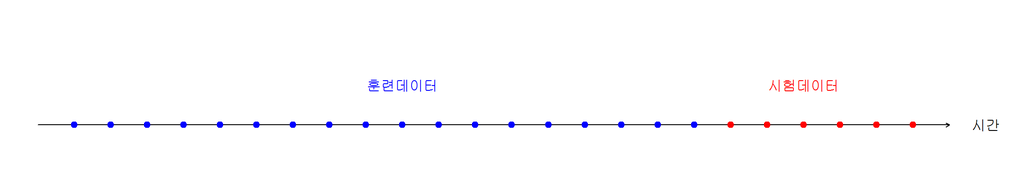

```r
train = 1:18
test = 19:24
par(mar=c(0,0,0,0))
plot(0,0,xlim=c(0,26),ylim=c(0,2),xaxt="n",yaxt="n",bty="n",xlab="",ylab="",type="n")
arrows(0,0.5,25,0.5,0.05)
points(train, train*0+0.5, pch=19, col="blue")
points(test,  test*0+0.5,  pch=19, col="red")
text(26,0.5,"시간")
text(10,1,"훈련데이터",col="blue")
text(21,1,"시험데이터",col="red")
```

## 1.2 시계열 훈련/시험 분할

**훈련/시험 누적 교차검증**

예측 정확도를 시험데이터에 대해서 평균을 내는 방법으로 “evaluation on a rolling forecasting origin”으로 알려져 있고, `tsCV()` 함수를 사용한다.

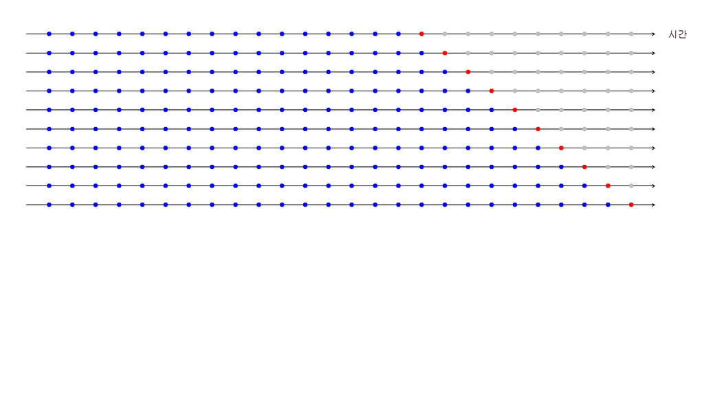

```r
par(mar=c(0,0,0,0))
plot(0,0,xlim=c(0,28),ylim=c(0,1),
     xaxt="n",yaxt="n",bty="n",xlab="",ylab="",type="n")
i <- 1
for(j in 1:10)
{
  test <- (16+j):26
  train <- 1:(15+j)
  arrows(0,1-j/20,27,1-j/20,0.05)
  points(train,rep(1-j/20,length(train)),pch=19,col="blue")
  if(length(test) >= i)
    points(test[i], 1-j/20, pch=19, col="red")
  if(length(test) >= i)
    points(test[-i], rep(1-j/20,length(test)-1), pch=19, col="gray")
  else
    points(test, rep(1-j/20,length(test)), pch=19, col="gray")
}
text(28,.95,"시간")
```

**훈련/시험 비누적 교차검증**

시간창(time windows)를 이동하면서 훈련/시험 비누적 교차검증 데이터를 작성하는 방식도 있다.

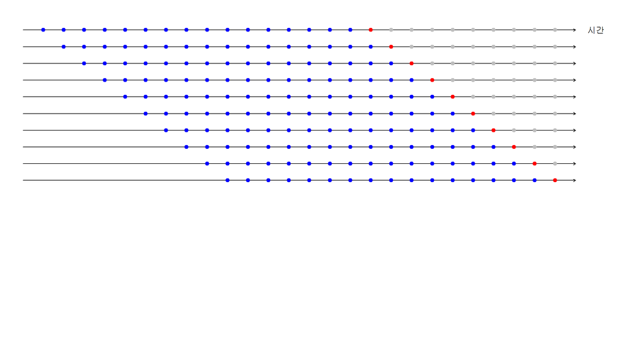

```r
par(mar=c(0,0,0,0))
plot(0,0,xlim=c(0,28),ylim=c(0,1),
     xaxt="n",yaxt="n",bty="n",xlab="",ylab="",type="n")
i <- 1
for(j in 1:10)
{
  test <- (16+j):26
  train <- j:(15+j)
  arrows(0,1-j/20,27,1-j/20,0.05)
  points(train,rep(1-j/20,length(train)),pch=19,col="blue")
  if(length(test) >= i)
    points(test[i], 1-j/20, pch=19, col="red")
  if(length(test) >= i)
    points(test[-i], rep(1-j/20,length(test)-1), pch=19, col="gray")
  else
    points(test, rep(1-j/20,length(test)), pch=19, col="gray")
}
text(28,.95,"시간")
```

# 2 시계열 데이터 분할 검정 [^1]

시계열계의 `iris` 붓꽃 데이터인 `AirPassenger` 항공여객 데이터를 훈련/시험 데이터로 분할해보자.

## 2.1 항공여객 데이터

`datasets` 팩키지에 포함된 `ts` 객체 항공여객 데이터(`AirPassengers`)를 `as_tbl_time()` 함수로 변환시켜 `ggplot`으로 시각화한다.

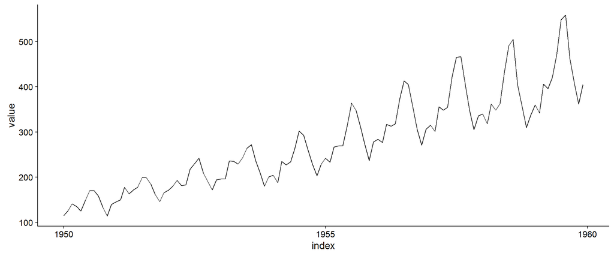

```r
# 0. 환경설정 -----
# Core Tidyverse
library(tidyverse)
library(glue)
library(forcats)

# Time Series
library(timetk)
library(tidyquant)
library(tibbletime)
library(sweep)

# Visualization
library(cowplot)

# Preprocessing
library(recipes)

# Sampling / Accuracy
library(rsample)
library(yardstick)

# Modeling
library(forecast)

# 1. 데이터 -----
## 1.1. 데이터 가져오기 ----
ap_ts  <- datasets::AirPassengers %>%
  tk_tbl() %>%
  mutate(index = as_date(index)) %>%
  as_tbl_time(index = index) %>%
  filter(index >= "1950-01-01",
         index <= "1959-12-31")

ggplot(ap_ts, aes(x=index, y=value)) +
  geom_line()
```

## 2.2 비누적 방식 훈련/검증 데이터 분할

항공여객 데이터를 `rsample` 팩키지를 활용하여 시계열 데이터를 분할시킨다. [rsample: Time Series Analysis Example](https://tidymodels.github.io/rsample/articles/Applications/Time_Series.html)을 참조하고, [TIME SERIES DEEP LEARNING, PART 1: FORECASTING SUNSPOTS WITH KERAS STATEFUL LSTM IN R](http://www.business-science.io/timeseries-analysis/2018/04/18/keras-lstm-sunspots-time-series-prediction.html) 블로그에서 공개된 R코드를 바탕으로 `rolling_origin()` 함수로 데이터를 훈련 검증 데이터로 나눈다. 2년치 데이터($12 \times 2$)를 훈련데이터로 활용하고, 1년치 데이터($12 \times 1$)를 모형 시험데이터로 사용한다. 그리고 `skip_span`을 통해 1년이면 12달이라 11달은 건너뛰고 1달만 사용한다는데, 주별 모형을 작성할 경우 7일이 일주일이라 6일은 건너뛰는 방식으로 사용하면 유용하다.

비누적방식으로 시계열 훈련/검증 데이터를 준비할 경우 `cumulative = FALSE`를 지정하면 지정한 시간창(time window)에 맞춰 훈련/시험 시계열 데이터가 준비된다.

```r
## 1.2. rsample 교차검증 데이터 ----
periods_train <- 12 * 2
periods_test  <- 12 * 1
skip_span     <- 11

rolling_origin_resamples <- rolling_origin(
  ap_ts ,
  initial    = periods_train,
  assess     = periods_test,
  cumulative = FALSE,
  skip       = skip_span
)
rolling_origin_resamples
```

```
# Rolling origin forecast resampling
# A tibble: 8 x 2
  splits       id
  <list>       <chr>
1 <S3: rsplit> Slice1
2 <S3: rsplit> Slice2
3 <S3: rsplit> Slice3
4 <S3: rsplit> Slice4
5 <S3: rsplit> Slice5
6 <S3: rsplit> Slice6
7 <S3: rsplit> Slice7
8 <S3: rsplit> Slice8
```

### 2.2.1 분할된 데이터 시각화

`plot_split()` 함수를 사용해서 시계열 훈련/검증 데이터셋으로 분할된 데이터일부를 시각화하여 의도한 것과 같이 분할이 된 것인지 확인한다.

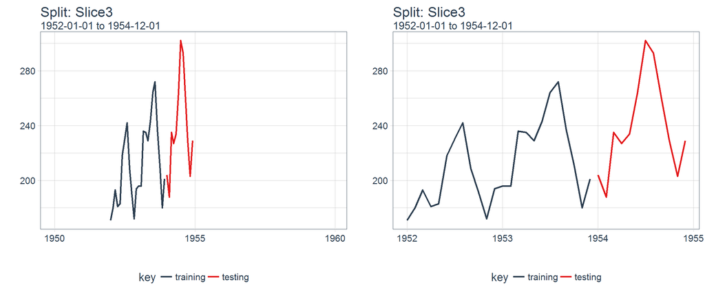

```r
# 2. 탐색적 데이터 분석 -----
plot_split <- function(split, expand_y_axis = TRUE, alpha = 1, size = 1, base_size = 14) {

  # Manipulate data
  train_tbl <- training(split) %>%
    add_column(key = "training")

  test_tbl  <- testing(split) %>%
    add_column(key = "testing")

  data_manipulated <- bind_rows(train_tbl, test_tbl) %>%
    as_tbl_time(index = index) %>%
    mutate(key = fct_relevel(key, "training", "testing"))

  # Collect attributes
  train_time_summary <- train_tbl %>%
    tk_index() %>%
    tk_get_timeseries_summary()

  test_time_summary <- test_tbl %>%
    tk_index() %>%
    tk_get_timeseries_summary()

  # Visualize
  g <- data_manipulated %>%
    ggplot(aes(x = index, y = value, color = key)) +
    geom_line(size = size, alpha = alpha) +
    theme_tq(base_size = base_size) +
    scale_color_tq() +
    labs(
      title    = glue("Split: {split$id}"),
      subtitle = glue("{train_time_summary$start} to {test_time_summary$end}"),
      y = "", x = ""
    ) +
    theme(legend.position = "none")

  if (expand_y_axis) {

    ap_time_summary <- ap_ts %>%
      tk_index() %>%
      tk_get_timeseries_summary()

    g <- g +
      scale_x_date(limits = c(ap_time_summary$start,
                              ap_time_summary$end))
  }

  return(g)
}

original_g <- rolling_origin_resamples$splits[[3]] %>%
  plot_split(expand_y_axis = TRUE) +
  theme(legend.position = "bottom")

rescaled_g <- rolling_origin_resamples$splits[[3]] %>%
  plot_split(expand_y_axis = FALSE) +
  theme(legend.position = "bottom")

plot_grid(original_g, rescaled_g)
```

### 2.2.2 분할된 전체 데이터 시각화

`plot_sampling_plan()` 함수를 작성하여 전체 시계열 훈련/검증 데이터셋으로 분할이 의도한 것과 같이 잘 분할된 것인지 확인한다.

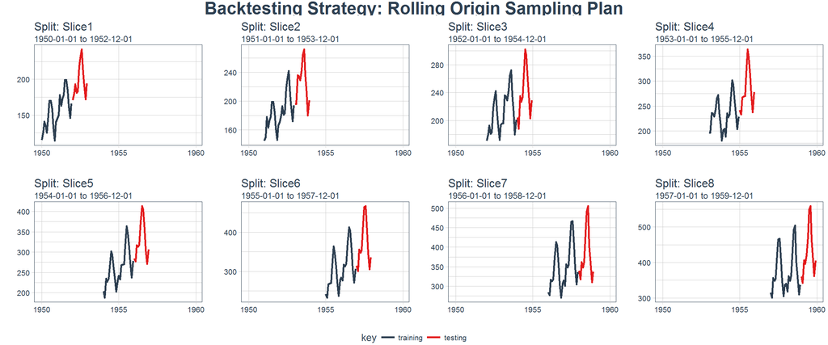

```r
plot_sampling_plan <- function(sampling_tbl, expand_y_axis = TRUE,
                               ncol = 3, alpha = 1, size = 1, base_size = 14,
                               title = "Sampling Plan") {

  # Map plot_split() to sampling_tbl
  sampling_tbl_with_plots <- sampling_tbl %>%
    mutate(gg_plots = map(splits, plot_split,
                          expand_y_axis = expand_y_axis,
                          alpha = alpha, base_size = base_size))

  # Make plots with cowplot
  plot_list <- sampling_tbl_with_plots$gg_plots

  p_temp <- plot_list[[1]] + theme(legend.position = "bottom")
  legend <- get_legend(p_temp)

  p_body  <- plot_grid(plotlist = plot_list, ncol = ncol)

  p_title <- ggdraw() +
    draw_label(title, size = 18, fontface = "bold", colour = palette_light()[[1]])

  g <- plot_grid(p_title, p_body, legend, ncol = 1, rel_heights = c(0.05, 1, 0.05))

  return(g)

}

rolling_origin_resamples %>%
  plot_sampling_plan(expand_y_axis = T, ncol = 4, alpha = 1, size = 1, base_size = 10,
                     title = "Backtesting Strategy: Rolling Origin Sampling Plan")
```

## 2.3 누적 방식 훈련/검증 데이터 분할

누적방식으로 시계열 훈련/검증 데이터를 준비할 경우 `cumulative = TRUE`를 지정하면, 지정한 시간창(time window)에 누적하여 훈련/시험 시계열 데이터가 준비된다.

```r
## 1.2. rsample 교차검증 데이터 ----
periods_train <- 12 * 2
periods_test  <- 12 * 1
skip_span     <- 11

rolling_origin_resamples <- rolling_origin(
  ap_ts ,
  initial    = periods_train,
  assess     = periods_test,
  cumulative = TRUE,
  skip       = skip_span
)
rolling_origin_resamples
```

```
# Rolling origin forecast resampling
# A tibble: 8 x 2
  splits       id
  <list>       <chr>
1 <S3: rsplit> Slice1
2 <S3: rsplit> Slice2
3 <S3: rsplit> Slice3
4 <S3: rsplit> Slice4
5 <S3: rsplit> Slice5
6 <S3: rsplit> Slice6
7 <S3: rsplit> Slice7
8 <S3: rsplit> Slice8
```

### 2.3.1 분할된 데이터 시각화

`plot_split()` 함수를 사용해서 시계열 훈련/검증 데이터셋으로 분할된 데이터일부를 시각화하여 의도한 것과 같이 분할이 된 것인지 확인한다.

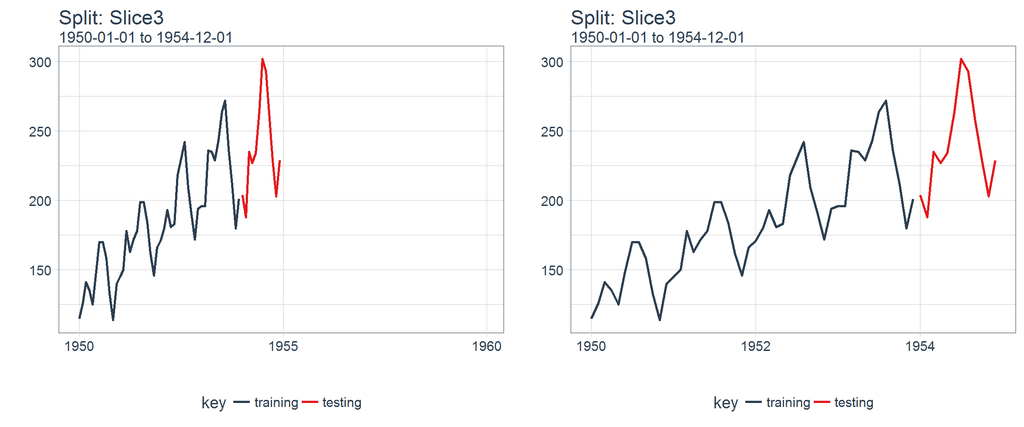

```r
# 2. 탐색적 데이터 분석 -----
plot_split <- function(split, expand_y_axis = TRUE, alpha = 1, size = 1, base_size = 14) {

  # Manipulate data
  train_tbl <- training(split) %>%
    add_column(key = "training")

  test_tbl  <- testing(split) %>%
    add_column(key = "testing")

  data_manipulated <- bind_rows(train_tbl, test_tbl) %>%
    as_tbl_time(index = index) %>%
    mutate(key = fct_relevel(key, "training", "testing"))

  # Collect attributes
  train_time_summary <- train_tbl %>%
    tk_index() %>%
    tk_get_timeseries_summary()

  test_time_summary <- test_tbl %>%
    tk_index() %>%
    tk_get_timeseries_summary()

  # Visualize
  g <- data_manipulated %>%
    ggplot(aes(x = index, y = value, color = key)) +
    geom_line(size = size, alpha = alpha) +
    theme_tq(base_size = base_size) +
    scale_color_tq() +
    labs(
      title    = glue("Split: {split$id}"),
      subtitle = glue("{train_time_summary$start} to {test_time_summary$end}"),
      y = "", x = ""
    ) +
    theme(legend.position = "none")

  if (expand_y_axis) {

    ap_time_summary <- ap_ts %>%
      tk_index() %>%
      tk_get_timeseries_summary()

    g <- g +
      scale_x_date(limits = c(ap_time_summary$start,
                              ap_time_summary$end))
  }

  return(g)
}

original_g <- rolling_origin_resamples$splits[[3]] %>%
  plot_split(expand_y_axis = TRUE) +
  theme(legend.position = "bottom")

rescaled_g <- rolling_origin_resamples$splits[[3]] %>%
  plot_split(expand_y_axis = FALSE) +
  theme(legend.position = "bottom")

plot_grid(original_g, rescaled_g)
```

### 2.3.2 분할된 전체 데이터 시각화

`plot_sampling_plan()` 함수를 작성하여 전체 시계열 훈련/검증 데이터셋으로 분할이 의도한 것과 같이 잘 분할된 것인지 확인한다.

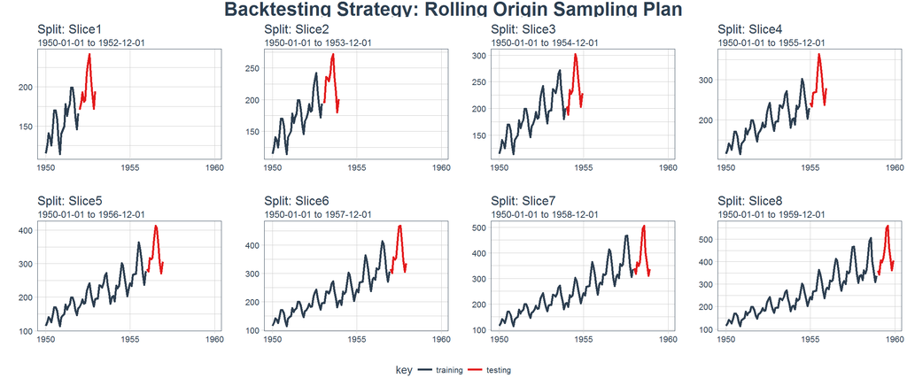

```r
plot_sampling_plan <- function(sampling_tbl, expand_y_axis = TRUE,
                               ncol = 3, alpha = 1, size = 1, base_size = 14,
                               title = "Sampling Plan") {

  # Map plot_split() to sampling_tbl
  sampling_tbl_with_plots <- sampling_tbl %>%
    mutate(gg_plots = map(splits, plot_split,
                          expand_y_axis = expand_y_axis,
                          alpha = alpha, base_size = base_size))

  # Make plots with cowplot
  plot_list <- sampling_tbl_with_plots$gg_plots

  p_temp <- plot_list[[1]] + theme(legend.position = "bottom")
  legend <- get_legend(p_temp)

  p_body  <- plot_grid(plotlist = plot_list, ncol = ncol)

  p_title <- ggdraw() +
    draw_label(title, size = 18, fontface = "bold", colour = palette_light()[[1]])

  g <- plot_grid(p_title, p_body, legend, ncol = 1, rel_heights = c(0.05, 1, 0.05))

  return(g)

}

rolling_origin_resamples %>%
  plot_sampling_plan(expand_y_axis = T, ncol = 4, alpha = 1, size = 1, base_size = 10,
                     title = "Backtesting Strategy: Rolling Origin Sampling Plan")
```

[^1]: [TIME SERIES DEEP LEARNING, PART 1: FORECASTING SUNSPOTS WITH KERAS STATEFUL LSTM IN R Written by Matt Dancho on April 18, 2018](http://www.business-science.io/timeseries-analysis/2018/04/18/keras-lstm-sunspots-time-series-prediction.html)